# INN Hotels Project

## Building a Decision Tree model

```python
#%reset
```

```python
hotel.info()
```

```
<class 'pandas.core.frame.DataFrame'>
Int64Index: 36238 entries, 0 to 36274
Data columns (total 21 columns):
 #   Column                                    Non-Null Count  Dtype
---  ------                                    --------------  -----
 0   no_of_adults                              36238 non-null  int64
 1   no_of_weekend_nights                      36238 non-null  int64
 2   no_of_week_nights                         36238 non-null  int64
 3   type_of_meal_plan                         36238 non-null  category
 4   required_car_parking_space                36238 non-null  int64
 5   room_type_reserved                        36238 non-null  category
 6   arrival_year                              36238 non-null  int64
 7   arrival_month                             36238 non-null  int64
 8   market_segment_type                       36238 non-null  category
 9   repeated_guest                            36238 non-null  int64
 10  avg_price_per_room                        36238 non-null  float64
 11  no_of_special_requests                    36238 non-null  int64
 12  booking_status                            36238 non-null  category
 13  Date                                      36238 non-null  datetime64[ns]
 14  DayofWeek                                 36238 non-null  category
 15  lead_time_bin                             36238 non-null  category
 16  no_of_children_bin                        36238 non-null  category
 17  no_of_previous_bookings_not_canceled_bin  36238 non-null  category
 18  no_of_previous_cancellations_bin          36238 non-null  category
 19  booking_status_encoded                    36238 non-null  int64
 20  target_binary                             36238 non-null  int64
dtypes: category(9), datetime64[ns](1), float64(1), int64(10)
memory usage: 3.9 MB
```

```python
drop_var = ["booking_status","Date", "booking_status_encoded"]
X = hotel.drop(drop_var, axis="columns")
y = hotel["booking_status_encoded"]

# Create dummy variables for object and category dtypes
X = pd.get_dummies(
    X,
    columns=X.select_dtypes(include=["object", "category"]).columns.tolist(),
    drop_first=True,
)
X.info()
```

```
<class 'pandas.core.frame.DataFrame'>
Int64Index: 36238 entries, 0 to 36274
Data columns (total 54 columns):
 #   Column                                               Non-Null Count  Dtype
---  ------                                               --------------  -----
 0   no_of_adults                                         36238 non-null  int64
 1   no_of_weekend_nights                                 36238 non-null  int64
 2   no_of_week_nights                                    36238 non-null  int64
 3   required_car_parking_space                           36238 non-null  int64
 4   arrival_year                                         36238 non-null  int64
 5   arrival_month                                        36238 non-null  int64
 6   repeated_guest                                       36238 non-null  int64
 7   avg_price_per_room                                   36238 non-null  float64
 8   no_of_special_requests                               36238 non-null  int64
 9   target_binary                                        36238 non-null  int64
```

[output cut: 46 more lines]

```python
pd.crosstab(X.market_segment_type_Online, y)
```

| booking_status_encoded market_segment_type_Online | 0 | 1 |
| --- | --- | --- |
| 0 | 3409 | 9635 |
| 1 | 8469 | 14725 |

```python
# split X and y into training and testing datasets split into .60 to .40 size
X_train, X_test, y_train, y_test = train_test_split(X, y, test_size=0.4, random_state=1)

print("Number of rows in train data =", X_train.shape[0])
print("Number of rows in test data =", X_test.shape[0])
print('*' * 50)
print("Percentage of classes in training set:")
print(y_train.value_counts(normalize=True))
print('*' * 50)
print("Percentage of classes in test set:")
print(y_test.value_counts(normalize=True))
```

```
Number of rows in train data = 21742
Number of rows in test data = 14496
Percentage of classes in training set:
1    0.671281
0    0.328719
Name: booking_status_encoded, dtype: float64
Percentage of classes in test set:
1    0.673634
0    0.326366
Name: booking_status_encoded, dtype: float64
```

```python
X_train, X_test, y_train, y_test = train_test_split(X, y, test_size=.30, random_state=1)
```

```python
X_train.columns.tolist()
```

```
['no_of_adults',
 'no_of_weekend_nights',
 'no_of_week_nights',
 'required_car_parking_space',
 'arrival_year',
 'arrival_month',
 'repeated_guest',
 'avg_price_per_room',
 'no_of_special_requests',
 'target_binary',
 'type_of_meal_plan_Meal Plan 2',
 'type_of_meal_plan_Meal Plan 3',
 'type_of_meal_plan_Not Selected',
 'room_type_reserved_Room_Type 2',
 'room_type_reserved_Room_Type 3',
 'room_type_reserved_Room_Type 4',
 'room_type_reserved_Room_Type 5',
 'room_type_reserved_Room_Type 6',
 'room_type_reserved_Room_Type 7',
 'market_segment_type_Complementary',
 'market_segment_type_Corporate',
 'market_segment_type_Offline',
 'market_segment_type_Online',
 'DayofWeek_Monday',
 'DayofWeek_Saturday',
 'DayofWeek_Sunday',
 'DayofWeek_Thursday',
 'DayofWeek_Tuesday',
 'DayofWeek_Wednesday',
 'lead_time_bin_30_to_90_days',
 'lead_time_bin_90_days_to_half_year',
 'lead_time_bin_half_year_to_year',
 'lead_time_bin_more_than_year',
 'no_of_children_bin_1',
 'no_of_children_bin_2',
 'no_of_children_bin_3',
 'no_of_children_bin_4 or more',
 'no_of_previous_bookings_not_canceled_bin_1',
 'no_of_previous_bookings_not_canceled_bin_2',
 'no_of_previous_bookings_not_canceled_bin_3',
 'no_of_previous_bookings_not_canceled_bin_4',
 'no_of_previous_bookings_not_canceled_bin_5',
 'no_of_previous_bookings_not_canceled_bin_6',
 'no_of_previous_bookings_not_canceled_bin_7',
 'no_of_previous_bookings_not_canceled_bin_8',
 'no_of_previous_bookings_not_canceled_bin_9',
 'no_of_previous_bookings_not_canceled_bin_10',
 'no_of_previous_bookings_not_canceled_bin_11 or more',
 'no_of_previous_cancellations_bin_1',
 'no_of_previous_cancellations_bin_2',
 'no_of_previous_cancellations_bin_3',
 'no_of_previous_cancellations_bin_4',
 'no_of_previous_cancellations_bin_5',
 'no_of_previous_cancellations_bin_6 or more']
```

```python
input_var = list(X_train.columns)
```

```python
input_var.remove('target_binary')
```

```python
input_var
```

```
['no_of_adults',
 'no_of_weekend_nights',
 'no_of_week_nights',
 'required_car_parking_space',
 'arrival_year',
 'arrival_month',
 'repeated_guest',
 'avg_price_per_room',
 'no_of_special_requests',
 'type_of_meal_plan_Meal Plan 2',
 'type_of_meal_plan_Meal Plan 3',
 'type_of_meal_plan_Not Selected',
 'room_type_reserved_Room_Type 2',
 'room_type_reserved_Room_Type 3',
 'room_type_reserved_Room_Type 4',
 'room_type_reserved_Room_Type 5',
 'room_type_reserved_Room_Type 6',
 'room_type_reserved_Room_Type 7',
 'market_segment_type_Complementary',
 'market_segment_type_Corporate',
 'market_segment_type_Offline',
 'market_segment_type_Online',
 'DayofWeek_Monday',
 'DayofWeek_Saturday',
 'DayofWeek_Sunday',
 'DayofWeek_Thursday',
 'DayofWeek_Tuesday',
 'DayofWeek_Wednesday',
 'lead_time_bin_30_to_90_days',
 'lead_time_bin_90_days_to_half_year',
 'lead_time_bin_half_year_to_year',
 'lead_time_bin_more_than_year',
 'no_of_children_bin_1',
 'no_of_children_bin_2',
 'no_of_children_bin_3',
 'no_of_children_bin_4 or more',
 'no_of_previous_bookings_not_canceled_bin_1',
 'no_of_previous_bookings_not_canceled_bin_2',
 'no_of_previous_bookings_not_canceled_bin_3',
 'no_of_previous_bookings_not_canceled_bin_4',
 'no_of_previous_bookings_not_canceled_bin_5',
 'no_of_previous_bookings_not_canceled_bin_6',
 'no_of_previous_bookings_not_canceled_bin_7',
 'no_of_previous_bookings_not_canceled_bin_8',
 'no_of_previous_bookings_not_canceled_bin_9',
 'no_of_previous_bookings_not_canceled_bin_10',
 'no_of_previous_bookings_not_canceled_bin_11 or more',
 'no_of_previous_cancellations_bin_1',
 'no_of_previous_cancellations_bin_2',
 'no_of_previous_cancellations_bin_3',
 'no_of_previous_cancellations_bin_4',
 'no_of_previous_cancellations_bin_5',
 'no_of_previous_cancellations_bin_6 or more']
```

```python
X_train = X_train[input_var]
X_test = X_test[input_var]
```

```python
X_train
```

|  | no_of_adults | no_of_weekend_nights | no_of_week_nights | required_car_parking_space | arrival_year | arrival_month | repeated_guest | avg_price_per_room | no_of_special_requests | type_of_meal_plan_Meal Plan 2 | ... | no_of_previous_bookings_not_canceled_bin_8 | no_of_previous_bookings_not_canceled_bin_9 | no_of_previous_bookings_not_canceled_bin_10 | no_of_previous_bookings_not_canceled_bin_11 or more | no_of_previous_cancellations_bin_1 | no_of_previous_cancellations_bin_2 | no_of_previous_cancellations_bin_3 | no_of_previous_cancellations_bin_4 | no_of_previous_cancellations_bin_5 | no_of_previous_cancellations_bin_6 or more |
| --- | --- | --- | --- | --- | --- | --- | --- | --- | --- | --- | --- | --- | --- | --- | --- | --- | --- | --- | --- | --- | --- |
| 4124 | 2 | 0 | 1 | 0 | 2017 | 10 | 0 | 67.00 | 0 | 0 | ... | 0 | 0 | 0 | 0 | 0 | 0 | 0 | 0 | 0 | 0 |
| 31349 | 3 | 0 | 4 | 0 | 2018 | 8 | 0 | 152.10 | 0 | 0 | ... | 0 | 0 | 0 | 0 | 0 | 0 | 0 | 0 | 0 | 0 |
| 10601 | 2 | 0 | 1 | 0 | 2018 | 2 | 0 | 90.00 | 0 | 0 | ... | 0 | 0 | 0 | 0 | 0 | 0 | 0 | 0 | 0 | 0 |
| 26095 | 2 | 0 | 4 | 0 | 2018 | 3 | 0 | 63.75 | 0 | 0 | ... | 0 | 0 | 0 | 0 | 0 | 0 | 0 | 0 | 0 | 0 |
| 9017 | 2 | 1 | 2 | 0 | 2018 | 5 | 0 | 125.33 | 1 | 0 | ... | 0 | 0 | 0 | 0 | 0 | 0 | 0 | 0 | 0 | 0 |
| ... | ... | ... | ... | ... | ... | ... | ... | ... | ... | ... | ... | ... | ... | ... | ... | ... | ... | ... | ... | ... | ... |
| 7818 | 2 | 0 | 1 | 0 | 2018 | 12 | 0 | 79.20 | 2 | 0 | ... | 0 | 0 | 0 | 0 | 0 | 0 | 0 | 0 | 0 | 0 |
| 32546 | 2 | 1 | 2 | 0 | 2018 | 12 | 0 | 105.00 | 1 | 0 | ... | 0 | 0 | 0 | 0 | 0 | 0 | 0 | 0 | 0 | 0 |
| 5194 | 2 | 0 | 2 | 0 | 2018 | 8 | 0 | 135.90 | 2 | 0 | ... | 0 | 0 | 0 | 0 | 0 | 0 | 0 | 0 | 0 | 0 |
| 12187 | 2 | 0 | 2 | 0 | 2017 | 8 | 0 | 109.00 | 0 | 1 | ... | 0 | 0 | 0 | 0 | 0 | 0 | 0 | 0 | 0 | 0 |
| 33038 | 2 | 0 | 3 | 0 | 2017 | 12 | 0 | 70.00 | 0 | 0 | ... | 0 | 0 | 0 | 0 | 0 | 0 | 0 | 0 | 0 | 0 |

25366 rows × 53 columns

```python
dTree = DecisionTreeClassifier(criterion = 'gini', random_state=1)
dTree.fit(X_train, y_train)
```

```
DecisionTreeClassifier(random_state=1)
```

```python
print("Accuracy on training set : ",dTree.score(X_train, y_train))
print("Accuracy on test set : ",dTree.score(X_test, y_test))
```

```
Accuracy on training set :  0.9840337459591579
Accuracy on test set :  0.8484179543782193
```

```python
y.sum(axis = 0)
```

```
24360
```

```python
## Function to create confusion matrix
def make_confusion_matrix(model,y_actual,labels=[1, 0]):
    '''
    model : classifier to predict values of X
    y_actual : ground truth

    '''
    y_predict = model.predict(X_test)
    cm=metrics.confusion_matrix( y_actual, y_predict, labels=[0, 1])
    df_cm = pd.DataFrame(cm, index = [i for i in ["Actual - No","Actual - Yes"]],
                  columns = [i for i in ['Predicted - No','Predicted - Yes']])
    group_counts = ["{0:0.0f}".format(value) for value in
                cm.flatten()]
    group_percentages = ["{0:.2%}".format(value) for value in
                         cm.flatten()/np.sum(cm)]
    labels = [f"{v1}\n{v2}" for v1, v2 in
              zip(group_counts,group_percentages)]
    labels = np.asarray(labels).reshape(2,2)
    plt.figure(figsize = (10,7))
    sns.heatmap(df_cm, annot=labels,fmt='')
    plt.ylabel('True label')
    plt.xlabel('Predicted label')
```

```python
##  Function to calculate recall score
def get_recall_score(model):
    '''
    model : classifier to predict values of X

    '''
    pred_train = model.predict(X_train)
    pred_test = model.predict(X_test)
    print("Recall on training set : ",metrics.recall_score(y_train,pred_train))
    print("Recall on test set : ",metrics.recall_score(y_test,pred_test))
```

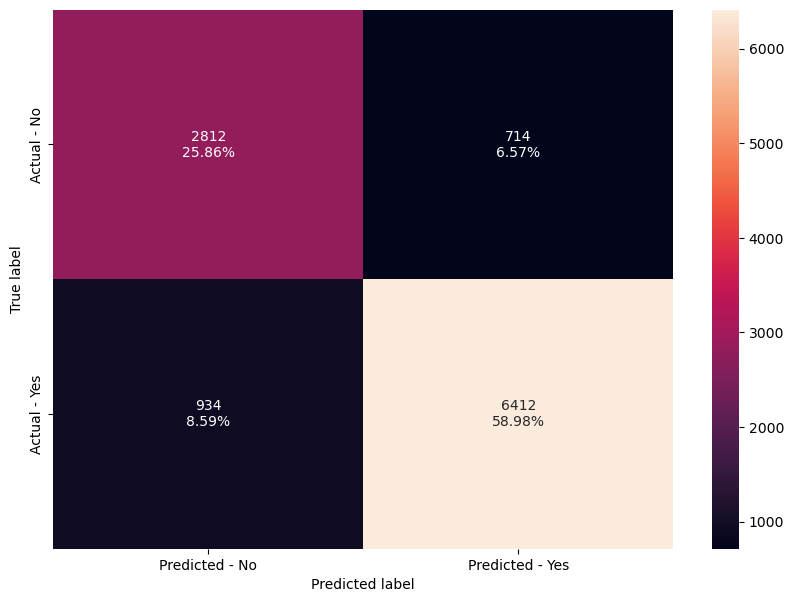

```python
make_confusion_matrix(dTree,y_test)
```

Observations:

As expected, the training data 's f1 score is very close to 1 while the testing data is nearing .90. While the model is capturing a good amount of test data, we can assume without tuning this model is overfitting.

```python
get_recall_score(dTree)
```

```
Recall on training set :  0.9828376631009756
Recall on test set :  0.8728559760413831
```

```python
feature_names = list(X.columns)
print(feature_names)
```

```
['no_of_adults', 'no_of_weekend_nights', 'no_of_week_nights', 'required_car_parking_space', 'arrival_year', 'arrival_month', 'repeated_guest', 'avg_price_per_room', 'no_of_special_requests', 'target_binary', 'type_of_meal_plan_Meal Plan 2', 'type_of_meal_plan_Meal Plan 3', 'type_of_meal_plan_Not Sel…
```

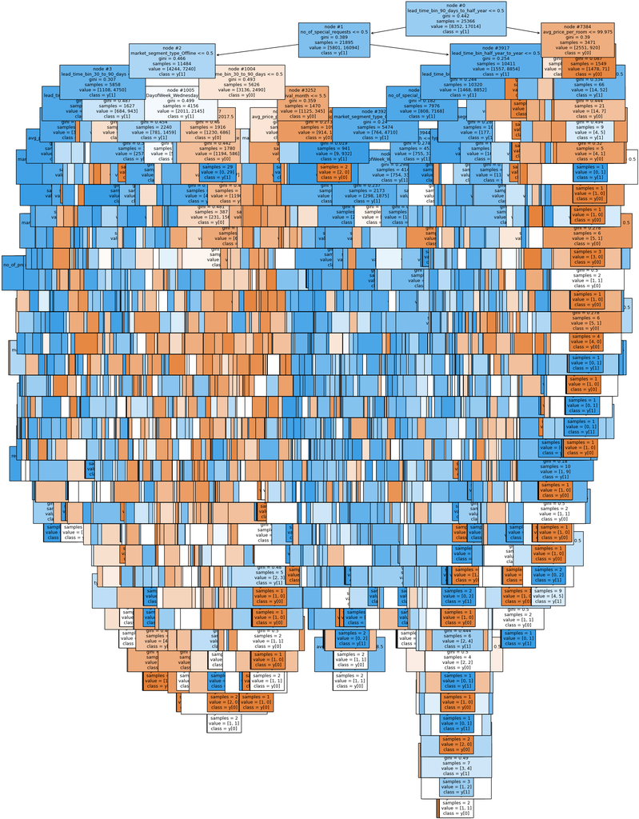

```python
plt.figure(figsize=(20,30))
tree.plot_tree(dTree,feature_names=feature_names,filled=True,fontsize=9,node_ids=True,class_names=True)
plt.show()
```

Observation:

Due to the overfitting, the decision tree branchs are very complex. Should look at limiting depth and post pruning

```python
print (pd.DataFrame(dTree.feature_importances_, columns = ["Imp"], index = X_train.columns).sort_values(by = 'Imp', ascending = False))
```

```
                                                         Imp
avg_price_per_room                                  0.223004
lead_time_bin_half_year_to_year                     0.123438
arrival_month                                       0.093673
market_segment_type_Online                          0.086968
no_of_special_requests                              0.079486
no_of_week_nights                                   0.066375
lead_time_bin_90_days_to_half_year                  0.049491
no_of_weekend_nights                                0.046831
no_of_adults                                        0.028078
lead_time_bin_30_to_90_days                         0.023718
arrival_year                                        0.022205
lead_time_bin_more_than_year                        0.020991
DayofWeek_Sunday                                    0.018047
DayofWeek_Thursday                                  0.014866
DayofWeek_Monday                                    0.013119
DayofWeek_Tuesday                                   0.011890
DayofWeek_Saturday                                  0.011656
room_type_reserved_Room_Type 4                      0.011427
type_of_meal_plan_Not Selected                      0.009746
DayofWeek_Wednesday                                 0.009333
required_car_parking_space                          0.007775
no_of_children_bin_1                                0.006239
market_segment_type_Offline                         0.005851
type_of_meal_plan_Meal Plan 2                       0.005137
room_type_reserved_Room_Type 2                      0.003268
market_segment_type_Corporate                       0.001618
no_of_children_bin_2                                0.001514
room_type_reserved_Room_Type 6                      0.001213
room_type_reserved_Room_Type 5                      0.001138
repeated_guest                                      0.000489
room_type_reserved_Room_Type 7                      0.000399
no_of_previous_cancellations_bin_1                  0.000344
no_of_previous_bookings_not_canceled_bin_1          0.000219
type_of_meal_plan_Meal Plan 3                       0.000186
room_type_reserved_Room_Type 3                      0.000142
no_of_previous_bookings_not_canceled_bin_11 or ...  0.000062
market_segment_type_Complementary                   0.000062
no_of_previous_bookings_not_canceled_bin_9          0.000000
no_of_previous_cancellations_bin_5                  0.000000
no_of_previous_cancellations_bin_4                  0.000000
no_of_previous_cancellations_bin_3                  0.000000
no_of_previous_cancellations_bin_2                  0.000000
no_of_previous_bookings_not_canceled_bin_10         0.000000
no_of_children_bin_3                                0.000000
no_of_previous_bookings_not_canceled_bin_8          0.000000
no_of_previous_bookings_not_canceled_bin_7          0.000000
no_of_previous_bookings_not_canceled_bin_6          0.000000
no_of_previous_bookings_not_canceled_bin_5          0.000000
no_of_previous_bookings_not_canceled_bin_4          0.000000
no_of_previous_bookings_not_canceled_bin_3          0.000000
no_of_previous_bookings_not_canceled_bin_2          0.000000
no_of_children_bin_4 or more                        0.000000
no_of_previous_cancellations_bin_6 or more          0.000000
```

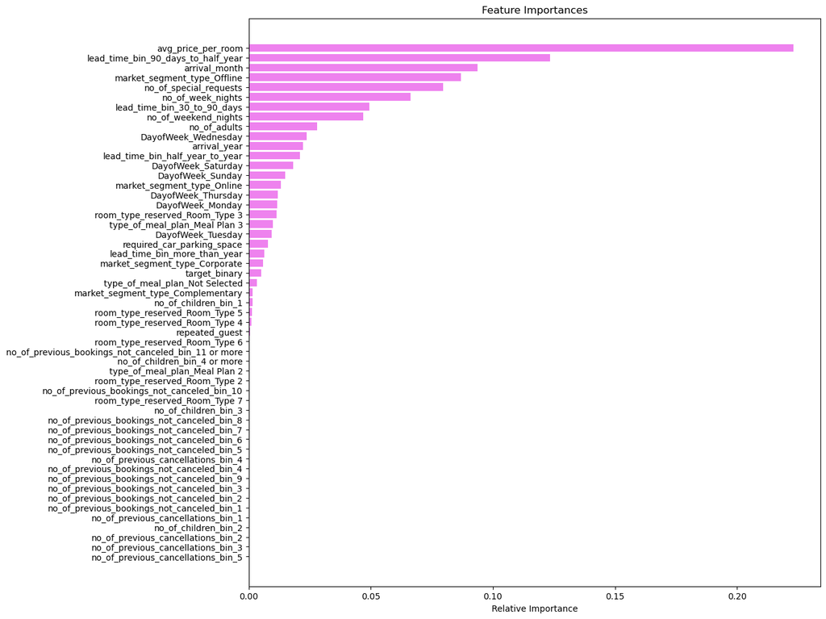

```python
# Gother the model's important variables and sort by importance
importances = dTree.feature_importances_
indices = np.argsort(importances)

# Plot importance variables
plt.figure(figsize=(12, 12))
plt.title("Feature Importances")
plt.barh(range(len(indices)), importances[indices], color="violet", align="center")
plt.yticks(range(len(indices)), [feature_names[i] for i in indices])
plt.xlabel("Relative Importance")
plt.show()
```

Observation:

```python
dTree1 = DecisionTreeClassifier(criterion = 'gini',max_depth=3,random_state=1)
dTree1.fit(X_train, y_train)
```

```
DecisionTreeClassifier(max_depth=3, random_state=1)
```

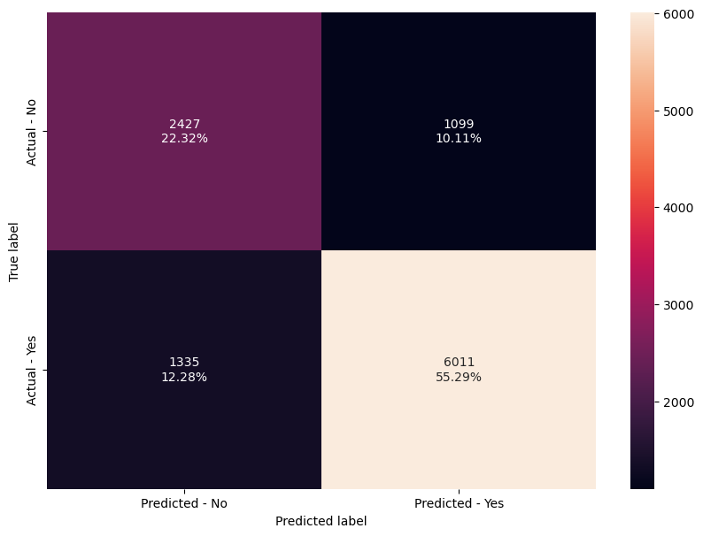

```python
make_confusion_matrix(dTree1, y_test)
```

```python
# Accuracy on train and test
print("Accuracy on training set : ",dTree1.score(X_train, y_train))
print("Accuracy on test set : ",dTree1.score(X_test, y_test))
# Recall on train and test
get_recall_score(dTree1)
```

```
Accuracy on training set :  0.7730426555231412
Accuracy on test set :  0.7761221486387049
Recall on training set :  0.8187375102856471
Recall on test set :  0.8182684454124693
```

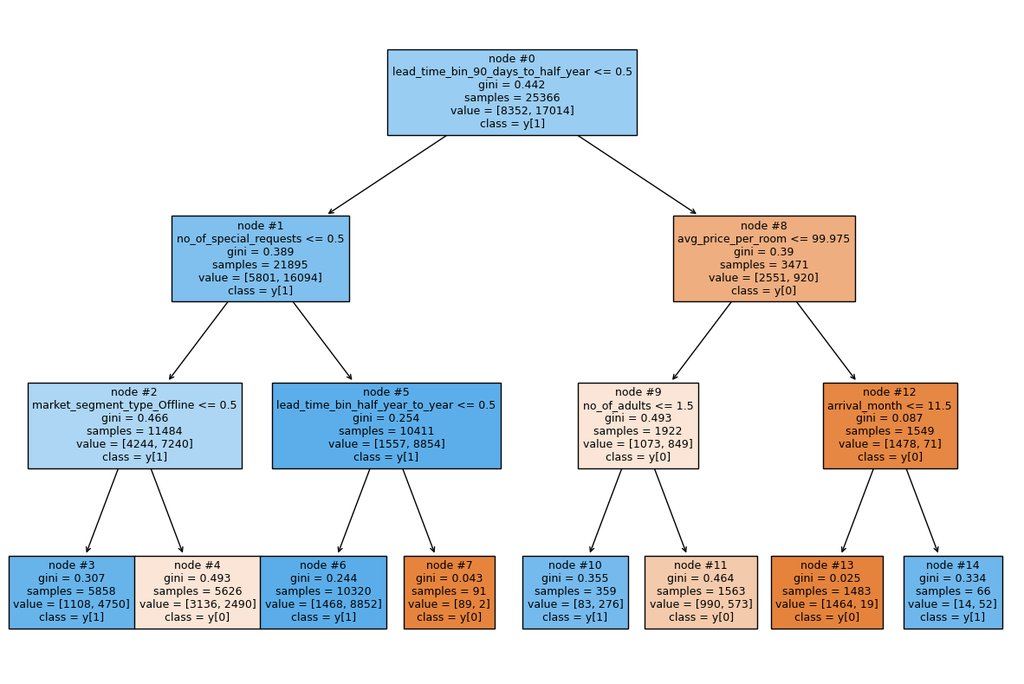

```python
plt.figure(figsize=(15,10))

tree.plot_tree(dTree1,feature_names=feature_names,filled=True,fontsize=9,node_ids=True,class_names=True)
plt.show()
```

```python
print (pd.DataFrame(dTree1.feature_importances_, columns = ["Imp"], index = X_train.columns).sort_values(by = 'Imp', ascending = False))
```

```
                                                         Imp
lead_time_bin_half_year_to_year                     0.414167
market_segment_type_Online                          0.243567
no_of_special_requests                              0.165400
avg_price_per_room                                  0.084127
lead_time_bin_more_than_year                        0.039431
no_of_adults                                        0.029554
arrival_month                                       0.023754
no_of_previous_cancellations_bin_2                  0.000000
no_of_previous_cancellations_bin_5                  0.000000
no_of_children_bin_1                                0.000000
no_of_children_bin_2                                0.000000
no_of_children_bin_3                                0.000000
no_of_children_bin_4 or more                        0.000000
no_of_previous_cancellations_bin_4                  0.000000
no_of_previous_bookings_not_canceled_bin_1          0.000000
no_of_previous_bookings_not_canceled_bin_2          0.000000
no_of_previous_bookings_not_canceled_bin_3          0.000000
no_of_previous_bookings_not_canceled_bin_4          0.000000
no_of_previous_bookings_not_canceled_bin_5          0.000000
no_of_previous_bookings_not_canceled_bin_6          0.000000
lead_time_bin_90_days_to_half_year                  0.000000
no_of_previous_bookings_not_canceled_bin_8          0.000000
no_of_previous_bookings_not_canceled_bin_9          0.000000
no_of_previous_bookings_not_canceled_bin_10         0.000000
no_of_previous_bookings_not_canceled_bin_11 or ...  0.000000
no_of_previous_cancellations_bin_1                  0.000000
no_of_previous_cancellations_bin_3                  0.000000
no_of_previous_bookings_not_canceled_bin_7          0.000000
DayofWeek_Tuesday                                   0.000000
lead_time_bin_30_to_90_days                         0.000000
DayofWeek_Wednesday                                 0.000000
no_of_week_nights                                   0.000000
required_car_parking_space                          0.000000
arrival_year                                        0.000000
repeated_guest                                      0.000000
type_of_meal_plan_Meal Plan 2                       0.000000
type_of_meal_plan_Meal Plan 3                       0.000000
type_of_meal_plan_Not Selected                      0.000000
room_type_reserved_Room_Type 2                      0.000000
room_type_reserved_Room_Type 3                      0.000000
room_type_reserved_Room_Type 4                      0.000000
room_type_reserved_Room_Type 5                      0.000000
room_type_reserved_Room_Type 6                      0.000000
room_type_reserved_Room_Type 7                      0.000000
market_segment_type_Complementary                   0.000000
market_segment_type_Corporate                       0.000000
market_segment_type_Offline                         0.000000
DayofWeek_Monday                                    0.000000
DayofWeek_Saturday                                  0.000000
DayofWeek_Sunday                                    0.000000
DayofWeek_Thursday                                  0.000000
no_of_weekend_nights                                0.000000
no_of_previous_cancellations_bin_6 or more          0.000000
```

```python
from sklearn.model_selection import GridSearchCV
```

```python
# Choose the type of classifier.
estimator = DecisionTreeClassifier(random_state=1)

# Grid of parameters to choose from
## add from article
parameters = {'max_depth': np.arange(1,10),
              'min_samples_leaf': [1, 2, 5, 7, 10,15,20],
              'max_leaf_nodes' : [2, 3, 5, 10],
              'min_impurity_decrease': [0.001,0.01,0.1]
             }

# Type of scoring used to compare parameter combinations
acc_scorer = metrics.make_scorer(metrics.recall_score)

# Run the grid search
grid_obj = GridSearchCV(estimator, parameters, scoring=acc_scorer,cv=5)
grid_obj = grid_obj.fit(X_train, y_train)

# Set the clf to the best combination of parameters
estimator = grid_obj.best_estimator_

# Fit the best algorithm to the data.
estimator.fit(X_train, y_train)
```

```
DecisionTreeClassifier(max_depth=1, max_leaf_nodes=2, min_impurity_decrease=0.1,
                       random_state=1)
```

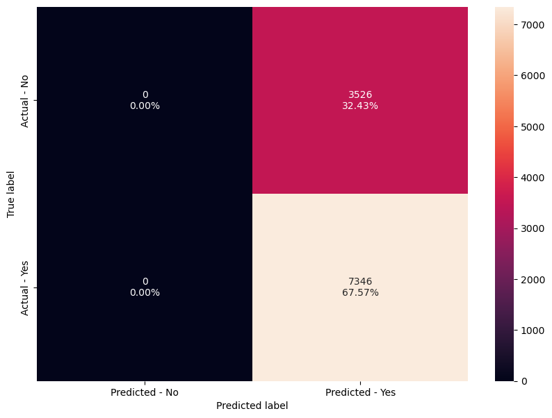

```python
make_confusion_matrix(estimator,y_test)
```

```python
# Accuracy on train and test
print("Accuracy on training set : ",estimator.score(X_train, y_train))
print("Accuracy on test set : ",estimator.score(X_test, y_test))
# Recall on train and test
get_recall_score(estimator)
```

```
Accuracy on training set :  0.6707403611133013
Accuracy on test set :  0.6756806475349522
Recall on training set :  1.0
Recall on test set :  1.0
```

```python
clf = DecisionTreeClassifier(random_state=1)
path = clf.cost_complexity_pruning_path(X_train, y_train)
ccp_alphas, impurities = path.ccp_alphas, path.impurities
```

```python
pd.DataFrame(path)
```

[output not shown]

```python
fig, ax = plt.subplots(figsize=(10,5))
ax.plot(ccp_alphas[:-1], impurities[:-1], marker='o', drawstyle="steps-post")
ax.set_xlabel("effective alpha")
ax.set_ylabel("total impurity of leaves")
ax.set_title("Total Impurity vs effective alpha for training set")
plt.show()
```

[output not shown]

```python
clfs = []
for ccp_alpha in ccp_alphas:
    clf = DecisionTreeClassifier(random_state=1, ccp_alpha=ccp_alpha)
    clf.fit(X_train, y_train)
    clfs.append(clf)
print(
    "Number of nodes in the last tree is: {} with ccp_alpha: {}".format(
        clfs[-1].tree_.node_count, ccp_alphas[-1]
    )
)
```

[output not shown]

```python
clfs = clfs[:-1]
ccp_alphas = ccp_alphas[:-1]

node_counts = [clf.tree_.node_count for clf in clfs]
depth = [clf.tree_.max_depth for clf in clfs]
fig, ax = plt.subplots(2, 1, figsize=(10, 7))
ax[0].plot(ccp_alphas, node_counts, marker="o", drawstyle="steps-post")
ax[0].set_xlabel("alpha")
ax[0].set_ylabel("number of nodes")
ax[0].set_title("Number of nodes vs alpha")
ax[1].plot(ccp_alphas, depth, marker="o", drawstyle="steps-post")
ax[1].set_xlabel("alpha")
ax[1].set_ylabel("depth of tree")
ax[1].set_title("Depth vs alpha")
fig.tight_layout()
```

[output not shown]

```python
f1_train = []
for clf in clfs:
    pred_train = clf.predict(X_train)
    values_train = f1_score(y_train, pred_train)
    f1_train.append(values_train)
```

```python
f1_test = []
for clf in clfs:
    pred_test = clf.predict(X_test)
    values_test = f1_score(y_test, pred_test)
    f1_test.append(values_test)
```

```python
# Plot F1_score & Alpha points to visualize the optimal alpha
fig, ax = plt.subplots(figsize=(15, 5))
ax.set_xlabel("alpha")
ax.set_ylabel("F1 S")
ax.set_title("F1 Score vs alpha for training and testing sets")
ax.plot(ccp_alphas, f1_train, marker="o", label="train", drawstyle="steps-post")
ax.plot(ccp_alphas, f1_test, marker="o", label="test", drawstyle="steps-post")
ax.legend()
plt.show()
```

[output not shown]

```python
# creating the model where we get highest train and test f1_score
index_best_model = np.argmax(f1_test)
best_model = clfs[index_best_model]
print(best_model)
```

[output not shown]

```python
performance_Matrix("Gini", best_model, X_train, y_train, X_test, y_test)
```

[output not shown]

```python
plt.figure(figsize=(10, 10))

out = tree.plot_tree(
    best_model,
    feature_names=feature_names,
    filled=True,
    fontsize=9,
    node_ids=True,
    class_names=True,
)
for o in out:
    arrow = o.arrow_patch
    if arrow is not None:
        arrow.set_edgecolor("black")
        arrow.set_linewidth(1)
plt.show()
```

[output not shown]

```python
importances = best_model.feature_importances_
indices = np.argsort(importances)

plt.figure(figsize=(12, 12))
plt.title("Feature Importances")
plt.barh(range(len(indices)), importances[indices], color="violet", align="center")
plt.yticks(range(len(indices)), [feature_names[i] for i in indices])
plt.xlabel("Relative Importance")
plt.show()
```

[output not shown]

```python
decision_tree_perf_train = model_performance_classification_statsmodels(
    model, X_train, y_train
)

decision_tree_tune_perf_train = model_performance_classification_statsmodels(
    estimator, X_train, y_train
)

decision_tree_postpruned_perf_train = model_performance_classification_statsmodels(
    best_model, X_train, y_train
)

# training performance comparison

models_train_comp_df = pd.concat(
    [
        decision_tree_perf_train.T,
        decision_tree_tune_perf_train.T,
        decision_tree_postpruned_perf_train.T,
    ],
    axis=1,
)
models_train_comp_df.columns = [
    "Decision Tree sklearn",
    "Decision Tree (Pre-Pruning)",
    "Decision Tree (Post-Pruning)",
]
print("Training performance comparison:")
models_train_comp_df
```

[output not shown]

```python
decision_tree_perf_test = model_performance_classification_statsmodels(
    model, X_test, y_test
)

decision_tree_tune_perf_test = model_performance_classification_statsmodels(
    estimator, X_test, y_test
)

decision_tree_postpruned_perf_test = model_performance_classification_statsmodels(
    best_model, X_test, y_test
)

# training performance comparison

models_test_comp_df = pd.concat(
    [
        decision_tree_perf_test.T,
        decision_tree_tune_perf_test.T,
        decision_tree_postpruned_perf_test.T,
    ],
    axis=1,
)
models_test_comp_df.columns = [
    "Decision Tree sklearn",
    "Decision Tree (Pre-Pruning)",
    "Decision Tree (Post-Pruning)",
]
print("Training performance comparison:")
models_test_comp_df
```

[output not shown]

Observation:

Knowing that lead time, price, and online bookings have the highest influence on cancellations we can infer that having cancellation clause during the online booking process would influence how customer's book. Keep price of rooms near competitive pricing as it seems like guest will be book a room with the expectation of continued searches. Since repeating_guests have a very low cancellation rate, creating a loyalty program for those guest would help incentives other to move into that category. During the online booking process, offering addtional customizations or special request would help reduce the likelihood of a cancelled booking.